# Multiple regression

Tutorial 6: exercises and solutions

Dr Massimiliano Canzi

## Setup

```r
library(tidyverse)
library(broom)
library(simling)
```

## The data

In `dgs_iconicity`, 30 deaf signers of German Sign Language (DGS) and 30 hearing people who do not sign rate 300 DGS signs for iconicity: how much a sign looks like what it means, from 1 (not at all) to 7 (very much). Deaf signers also rated each sign’s age of acquisition (`aoa`, in years). The code below makes one row per sign, with the mean rating of each group:

```r
signs <- dgs_iconicity |>
  summarise(rating = mean(rating), .by = c(sign, aoa, group)) |>
  pivot_wider(names_from = group, values_from = rating) |>
  rename(signers = `deaf signer`, non_signers = `hearing non-signer`)
glimpse(signs)
```

```
Rows: 300
Columns: 4
$ sign        <fct> sign001, sign002, sign003, sign004, sign005, sig…
$ aoa         <dbl> 4.5, 6.9, 5.0, 8.8, 6.8, 6.4, 3.7, 5.2, 2.3, 5.7…
$ signers     <dbl> 5.666667, 5.266667, 4.500000, 2.933333, 6.266667…
$ non_signers <dbl> 4.266667, 3.800000, 5.133333, 1.900000, 3.733333…
```

Today’s question: are iconic signs learned earlier, and which group’s ratings tell us more about it?

# 1. Two predictors

## 1.1 Two scatterplots

Plot `aoa` against `signers`, and in a second plot against `non_signers`. Label the axes in words. Are more iconic signs learned earlier or later?

## 1.1 Solution

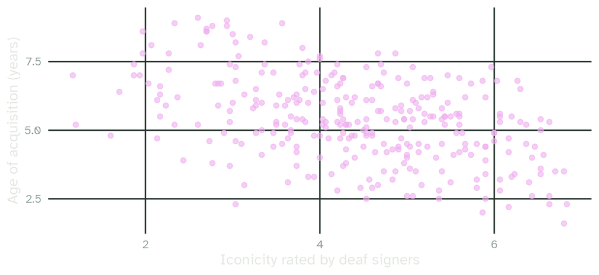

```r
signs |>
  ggplot(aes(x = signers, y = aoa)) +
  geom_point(colour = "plum2", alpha = 0.6) +
  xlab("Iconicity rated by deaf signers") + ylab("Age of acquisition (years)")
```

## 1.1 Solution

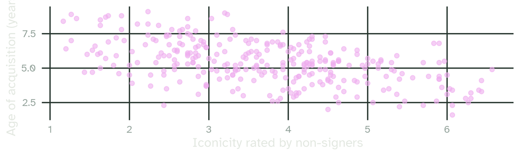

```r
signs |>
  ggplot(aes(x = non_signers, y = aoa)) +
  geom_point(colour = "plum2", alpha = 0.6) +
  xlab("Iconicity rated by non-signers") + ylab("Age of acquisition (years)")
```

In both plots, signs rated as more iconic tend to be learned earlier.

## 1.2 Correlated predictors

Compute the correlation between `signers` and `non_signers`. Do the two groups agree on which signs are iconic?

## 1.2 Solution

```r
cor(signs$signers, signs$non_signers)
```

```
[1] 0.7814731
```

They agree to a large extent: the correlation is 0.78. Signs that one group finds iconic, the other group tends to find iconic too.

## 1.3 Two simple regressions

Fit two models: `aoa` as a function of `signers`, and `aoa` as a function of `non_signers`. Print the coefficients of each. What does each slope say?

## 1.3 Solution

```r
m_s <- lm(aoa ~ signers, data = signs)
m_n <- lm(aoa ~ non_signers, data = signs)
coef(m_s)
```

```
(Intercept)     signers
  7.9052897  -0.5687162
```

```r
coef(m_n)
```

```
(Intercept) non_signers
  7.7590474  -0.6384045
```

One point more on the signers’ iconicity scale goes with signs learned 0.57 years earlier; one point more on the non-signers’ scale, 0.64 years earlier.

# 2. One model, two predictors

## 2.1 Multiple regression

Fit one model of `aoa` with both `signers` and `non_signers` as predictors and save it as `m`. Compare its slopes with the slopes from 1.3. What happened?

## 2.1 Solution

```r
m <- lm(aoa ~ signers + non_signers, data = signs)
coef(m)
```

```
(Intercept)     signers non_signers
  8.0349039  -0.1821138  -0.4957797
```

Both slopes are closer to 0 than in the simple regressions, and the slope of `signers` shrinks most: from 0.57 to 0.18 years per point.

## 2.2 Holding the other predictor constant

Complete the sentence for the slope of `signers` in `m`: “For signs that *, one point more on the signers’ scale goes with* .” Why are both slopes smaller than in 1.3?

## 2.2 Solution

For signs that non-signers rate the same, one point more on the signers’ scale goes with signs learned 0.18 years earlier.

The two ratings largely measure the same thing. In a simple regression, each rating gets credit for the part of iconicity it shares with the other one. In `m`, each slope only counts what that rating adds to the other.

## 2.3 Predictions

Predict the age of acquisition of a sign that both groups rate at 2 and of a sign that both groups rate at 6.

## 2.3 Solution

```r
predict(m, newdata = tibble(signers = c(2, 6), non_signers = c(2, 6)))
```

```
       1        2
6.679117 3.967543
```

The model predicts that a sign that both groups find very iconic is learned about 2.7 years earlier than one that both groups find hardly iconic.

# 3. Model fit and collinearity

## 3.1 `R²` and adjusted `R²`

Use `glance()` to get `R²` and adjusted `R²` for `m_s`, `m_n` and `m`. Does the second predictor improve the model much?

## 3.1 Solution

```r
glance(m_s)[, 1:2]
```

```
# A tibble: 1 × 2
  r.squared adj.r.squared
      <dbl>         <dbl>
1     0.210         0.208
```

```r
glance(m_n)[, 1:2]
```

```
# A tibble: 1 × 2
  r.squared adj.r.squared
      <dbl>         <dbl>
1     0.264         0.262
```

```r
glance(m)[, 1:2]
```

```
# A tibble: 1 × 2
  r.squared adj.r.squared
      <dbl>         <dbl>
1     0.272         0.268
```

## 3.1 Solution

`m` explains 27% of the variance in `aoa` (adjusted), only a little more than `m_n` with 26%. Once we know the non-signers’ rating, the signers’ rating adds little.

## 3.2 Standard errors

Use `tidy()` on `m_s` and on `m`. How does the standard error of the `signers` slope change? Why?

## 3.2 Solution

```r
tidy(m_s)
```

```
# A tibble: 2 × 5
  term        estimate std.error statistic  p.value
  <chr>          <dbl>     <dbl>     <dbl>    <dbl>
1 (Intercept)    7.91     0.293      27.0  4.61e-82
2 signers       -0.569    0.0638     -8.91 5.06e-17
```

```r
tidy(m)
```

```
# A tibble: 3 × 5
  term        estimate std.error statistic  p.value
  <chr>          <dbl>     <dbl>     <dbl>    <dbl>
1 (Intercept)    8.03     0.283      28.4  1.00e-86
2 signers       -0.182    0.0983     -1.85 6.50e- 2
3 non_signers   -0.496    0.0985     -5.03 8.46e- 7
```

The standard error grows from 0.064 to 0.098. The two predictors are strongly correlated, so the data contain little information about what each one does on its own. This is collinearity.

## 3.3 Bonus: VIF by hand

The variance inflation factor (VIF) of a predictor is 1 / (1 − R²), where R² comes from a model that predicts it from the other predictors. Compute the VIF of `signers` in `m`.

## 3.3 Solution

```r
r2 <- glance(lm(signers ~ non_signers, data = signs))$r.squared
1 / (1 - r2)
```

```
[1] 2.568714
```

A VIF of 2.6 means that the variance of the `signers` slope is 2.6 times as large as it would be without collinearity. That is noticeable but not alarming.

## 3.4 Bonus: one iconicity score

When two predictors measure the same thing, you can combine them. Make a column `iconicity`, the mean of `signers` and `non_signers`, and fit a model of `aoa` with `iconicity` as its only predictor. Compare its adjusted `R²` with that of `m`.

## 3.4 Solution

```r
signs <- signs |>
  mutate(iconicity = (signers + non_signers) / 2)
m_i <- lm(aoa ~ iconicity, data = signs)
coef(m_i)
```

```
(Intercept)   iconicity
  8.1449023  -0.6775131
```

```r
glance(m_i)$adj.r.squared
```

```
[1] 0.263041
```

One predictor fits about as well as two (26% against 27%), and its slope is easy to read: one point more iconicity goes with signs learned 0.68 years earlier.

## Reading

This tutorial goes with chapter 6 of Winter (2019).

Winter, B. (2019). *Statistics for linguists: An introduction using R*. Routledge. https://doi.org/10.4324/9781315165547

## Slides and exercises

[figure not shown]

These slides

mcanzi.de/statistics/tutorials/06_multiple_regression.html

Exercise sheet (R Markdown)

mcanzi.de/statistics/tutorials/06_multiple_regression.Rmd